# Make It Personal: Boston Index Results

Erik Thulin, ethulin@rare.org

Rakhim Rakhimov, rrakhimov@rare.org

05 July, 2022

### Research Overview

- Sampled 1,155 adult residents of the Boston core-based statistical area (CBSA), quota matched on age, gender, and ethnicity and weighted by ZIP
- For each MIP behavior:
  - Measured current self-reported *adoption*, *intention to adopt in the future*, and three social expectation measures - *belief that others are adopting the behavior*, *belief that others should adopt the behavior*, and *belief that others think people should adopt the behavior*
  - Measured stated *interest in participating in a program* that helps adopt the behavior
- For six out of seven MIP behaviors, measured perceived relative *carbon mitigation impact* of that behavior compared to a list of low-impact behaviors

### Results Overview

#### General trends

- Higher reported adoption of MIP behaviors among Boston residents compared to the general population
  - Reported flying frequency and food waste reduction measures are not reported due to the difference in survey items between the two samples

| Behavior | Boston sample | General population |
| --- | --- | --- |
| % of households that own at least 1 EV | 15% | 11% |
| % of people that bought a carbon offset in the last year | 6% | 2% |
| % of households that get electricity from a green energy provider | 15% | 9% |
| % of households that have solar panels | 11% | 4% |
| % of people's meals that do not include meat | 5% | 6% |

- Lack of awareness about the relative climate impact of low-impact and high-impact behaviors
  - People underestimate the impact of several MIP actions, including flying less and eating less meat
  - Lack of knowledge about how carbon offsets work
  - People overestimate the impact of low-impact behaviors, including recycling, replacing bulbs, and planting trees
- People underestimate how many people think they should adopt the behaviors
  - There is a large difference between the *perceived % of the population thinking people should adopt these behaviors* and the *actual % of the population thinking people should adopt the behaviors*

#### Program interest

- Interest in one program is predictive of interest in another program
  - People that are interested in one program are also likely to be interested in another program
- Program interest is the highest for buying an EV, reducing food waste, and contracting for green energy
- Program interest is the lowest for installing solar, buying offsets, eating less meat, and flying less frequently
- Beliefs about what should be done and beliefs about what other’s think should be done predict the interest
- Income does not predict program interest
- Ethnicity is a weak predictor of interest
- Education is predictive of program interest
  - This is especially true for those with graduate degrees
  - Education confounds the relationship between income and program interest (Once we add education into the linear regression, coefficients for income are reduced)
- Participation in and donation to religious groups is not correlated with program interest
- Participation in and donation to other social organizations is weakly correlated with program interest
- Being retired is negatively correlated with interest in programs and intention to adopt the behaviors

#### Intention to adopt

- Intention to adopt the behaviors is the highest for reducing food waste and flying less
- Intention to adopt is moderate for purchasing an EV, eating less meat, and contracting for green energy
- Intention to adopt is the lowest for offsets and solar panels
- Moderate correlations between various behaviors, suggesting that some behaviors could be offered in a bundle:
  - Buy an EV and buy offsets
  - Buy offsets and install solar
  - Eat less meat and reduce food waste
  - Contract for green energy and install solar
- All three social expectations are moderate predictors of intention to adopt the behaviors

### Results in Detail

#### Program Participation Interest

##### How interested would you be in participating in a program which helps you *[adopt behavior]*?

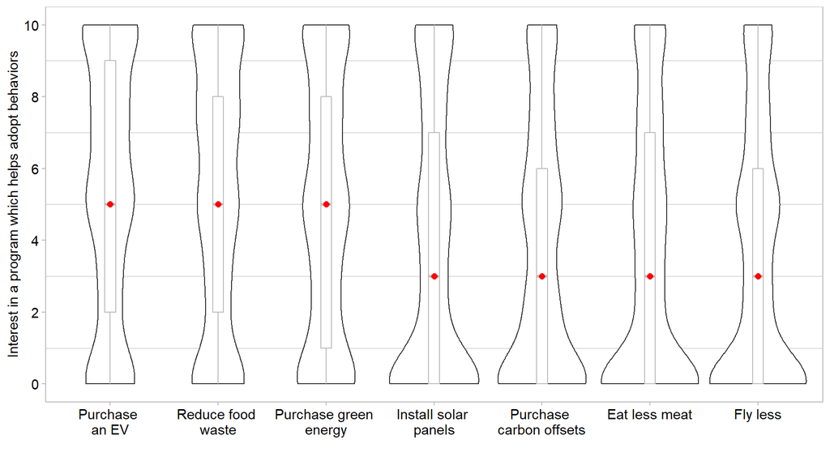

#### Boston Index

The survey was fielded from March 31 – April 21, 2021, drawing on the stratified sample of the Boston CBSA (n = 1,155)

| Behavior | Adoption | Intention | Others have adopted | Others should adopt | Others think people should adopt | Program interest | Carbon impact ranking |
| --- | --- | --- | --- | --- | --- | --- | --- |
| Purchase an EV | 0.15916898728745 | 0.393858442747479 | 0.179613633497246 | 0.606985535377869 | 0.371537232571795 | 0.532302856527286 | 0.545085369714514 |
| Fly less | 0.515271924614347 | 0.452061777164233 | 0.410718039918784 | 0.499567420471985 | 0.340743380021259 | 0.359761504760072 | 0.351702580483728 |
| Waste less food | 0.759770752368675 | 0.55052535230562 | 0.423708148614794 | 0.87618402801923 | 0.497155026358811 | 0.527257725486538 | NA |
| Purchase carbon offsets | 0.0568698652710344 | 0.247700308699061 | 0.180797401384042 | 0.616311279680845 | 0.315478165143994 | 0.371074806055223 | 0.446706480071072 |
| Eat less meat | 0.457942813705822 | 0.371083732587835 | 0.367921442261618 | 0.483397551671167 | 0.364371293900514 | 0.363157921755982 | 0.315287329496359 |
| Purchase green energy | 0.153671252841146 | 0.365372305653839 | 0.328968967368776 | 0.800371569915653 | 0.455061987575318 | 0.482765486697256 | 0.612781165234017 |
| Install solar panels | 0.102153594158372 | 0.217591047276759 | 0.284275773186059 | 0.604626269529986 | 0.379437751123379 | 0.38038370150583 | 0.642446223014983 |

For eating less meat, flying less, and reducing food waste, adoption variable measured current attempt, rather than reported adoption (e.g., *Are you trying to fly less frequently than you used to?*)

#### Carbon Impact Ranking

The table below presents the average ranking in terms of the carbon mitigation potential of MIP (highlighted) and low-impact behaviors assigned by participants. For example, on average, installing rooftop solar was assigned rank 4.61 out of 12.

| Behavior | Average position |
| --- | --- |
| Replace 25 incandescent light bulbs with ENERGY STAR lights | 6.52238805970149 |
| Drive a fully electric car for one year | 5.92098331870061 |
| Take one fewer round-trip flight | 8.18525021949078 |
| Replace old refrigerator with ENERGY STAR refrigerator | 6.78489903424056 |
| Source all of food locally for one year | 7.28358208955224 |
| Purchase carbon offsets to offset average American’s annual carbon footprint | 7.07638279192274 |
| Eliminate all food packaging for one year | 7.19490781387182 |
| Avoid eating all meat for one year | 8.55223880597015 |
| Purchase 100% of household energy from renewable sources for one year | 5.14135206321335 |
| Recycle 100% of recyclable materials generated as waste, including newspaper, magazines, glass, plastic, and metal for one year | 4.67778753292362 |

[output cut: 2 more lines]

#### Correlation tables

##### Pearson correlations between reported intention to engage in the behaviors

|  | Intention to drive an EV | Intention to fly less | Intention to buy offsets | Intention to eat less meat | Intention to contract for green energy | Intention to install solar | Intention to reduce food waste |
| --- | --- | --- | --- | --- | --- | --- | --- |
| Intention to drive an EV | 1 | 0.29 | 0.46 | 0.36 | 0.4 | 0.38 | 0.37 |
| Intention to fly less | 0.29 | 1 | 0.25 | 0.38 | 0.23 | 0.16 | 0.32 |
| Intention to buy offsets | 0.46 | 0.25 | 1 | 0.38 | 0.48 | 0.55 | 0.39 |
| Intention to eat less meat | 0.36 | 0.38 | 0.38 | 1 | 0.33 | 0.26 | 0.45 |
| Intention to contract for green energy | 0.4 | 0.23 | 0.48 | 0.33 | 1 | 0.53 | 0.42 |
| Intention to install solar | 0.38 | 0.16 | 0.55 | 0.26 | 0.53 | 1 | 0.34 |
| Intention to reduce food waste | 0.37 | 0.32 | 0.39 | 0.45 | 0.42 | 0.34 | 1 |

##### Pearson correlations between interest in programs that help adopt the behaviors

|  | Interest in EV program | Interest in fly less program | Interest in offsets program | Interest in eat less meat program | Interest in green energy program | Interest in solar program | Interest in reducing food waste program |
| --- | --- | --- | --- | --- | --- | --- | --- |
| Interest in EV program | 1 | 0.5 | 0.56 | 0.45 | 0.62 | 0.55 | 0.54 |
| Interest in fly less program | 0.5 | 1 | 0.52 | 0.49 | 0.53 | 0.46 | 0.5 |
| Interest in offsets program | 0.56 | 0.52 | 1 | 0.55 | 0.64 | 0.57 | 0.59 |
| Interest in eat less meat program | 0.45 | 0.49 | 0.55 | 1 | 0.54 | 0.44 | 0.59 |
| Interest in green energy program | 0.62 | 0.53 | 0.64 | 0.54 | 1 | 0.66 | 0.71 |
| Interest in solar program | 0.55 | 0.46 | 0.57 | 0.44 | 0.66 | 1 | 0.59 |
| Interest in reducing food waste program | 0.54 | 0.5 | 0.59 | 0.59 | 0.71 | 0.59 | 1 |

##### Pearson correlations between demographic and psychographic predictors and behavior-related variables

| Predictor | Interest in EV program | Interest in solar program | Interest in green energy program | Interest in offsets program | Interest in flying less program | Interest in eating less meat program | Interest in reducing food waste program | Intention to buy an EV | Intention to install solar | Intention to contract for green energy | Intention to buy offsets | Intention to fly less | Intention to eat less meat | Intention to reduce food waste | Beliefs that others drive an EV | Beliefs that others have solar | Beliefs that others have green energy | Beliefs that others bought offsets | Beliefs that others are flying less | Beliefs that others eat less meat | Beliefs that others reduce food waste | Beliefs that others should drive an EV | Beliefs that others should install solar | Beliefs that others should have green energy | Beliefs that others should buy offsets | Beliefs that others should fly less | Beliefs that others should eat less meat | Beliefs that others should reduce food waste | Beliefs that others think people should drive an EV | … |
| --- | --- | --- | --- | --- | --- | --- | --- | --- | --- | --- | --- | --- | --- | --- | --- | --- | --- | --- | --- | --- | --- | --- | --- | --- | --- | --- | --- | --- | --- | --- |
| Age: 18-24 | -0.05 | 0 | -0.11 | 0 | -0.04 | -0.1 | -0.08 | 0.06 | 0.09 | -0.04 | 0.02 | -0.02 | -0.05 | -0.03 | 0.15 | 0.07 | 0.06 | 0.12 | 0.02 | 0.03 | 0.03 | 0.11 | 0.14 | 0.1 | 0.08 | 0.08 | -0.02 | 0.01 | 0.1 | … |
| Age: 25-34 | 0.13 | 0.1 | 0.09 | 0.09 | 0.06 | 0.06 | 0.06 | 0.11 | 0.09 | 0.06 | 0.14 | -0.01 | 0.04 | 0.06 | 0.04 | 0.1 | 0.09 | 0.09 | 0.02 | 0.08 | 0.08 | 0.1 | 0.12 | 0.1 | 0.12 | 0.02 | 0.06 | 0.03 | 0.03 | … |
| Age: 35-44 | 0.1 | 0.1 | 0.09 | 0.12 | 0.06 | 0.04 | 0.08 | 0.07 | 0.15 | 0.05 | 0.12 | -0.02 | -0.02 | 0.01 | 0.04 | 0.05 | 0.01 | 0.05 | 0.01 | -0.01 | -0.01 | 0.08 | 0.03 | 0.04 | 0.06 | 0.01 | -0.01 | 0 | 0.02 | … |
| Age: 45-54 | 0.04 | 0.05 | 0.07 | 0.03 | 0.02 | 0.04 | 0.06 | 0 | 0.03 | 0.07 | -0.01 | -0.01 | -0.03 | 0.04 | -0.04 | -0.01 | 0 | -0.04 | -0.02 | -0.09 | -0.02 | -0.03 | 0.01 | -0.02 | -0.04 | -0.03 | 0 | -0.01 | -0.02 | … |
| Age: 55-64 | -0.09 | -0.06 | -0.04 | -0.09 | -0.05 | -0.02 | -0.07 | -0.08 | -0.11 | -0.02 | -0.12 | 0.03 | 0.03 | -0.04 | -0.07 | -0.07 | -0.02 | -0.1 | 0.01 | 0.02 | -0.04 | -0.08 | -0.07 | -0.05 | -0.09 | -0.05 | -0.05 | -0.03 | -0.05 | … |
| Age: 65+ | -0.12 | -0.17 | -0.1 | -0.13 | -0.05 | -0.02 | -0.04 | -0.13 | -0.22 | -0.11 | -0.13 | 0.03 | 0.03 | -0.03 | -0.09 | -0.12 | -0.13 | -0.11 | -0.03 | -0.02 | -0.03 | -0.17 | -0.19 | -0.14 | -0.12 | -0.02 | 0.02 | 0 | -0.06 | … |
| Female | -0.11 | -0.11 | -0.03 | -0.04 | -0.07 | 0.06 | 0.05 | -0.1 | -0.09 | -0.05 | -0.07 | -0.01 | 0.11 | 0.04 | -0.04 | -0.02 | -0.04 | -0.05 | -0.07 | 0.03 | 0.03 | -0.05 | -0.08 | 0.01 | 0.04 | -0.03 | 0.08 | 0.01 | -0.11 | … |
| Male | 0.11 | 0.11 | 0.03 | 0.04 | 0.07 | -0.06 | -0.05 | 0.1 | 0.09 | 0.05 | 0.07 | 0.01 | -0.11 | -0.04 | 0.04 | 0.02 | 0.04 | 0.05 | 0.07 | -0.03 | -0.03 | 0.05 | 0.08 | -0.01 | -0.04 | 0.03 | -0.08 | -0.01 | 0.11 | … |
| Ethnicity: White | -0.06 | -0.04 | 0.01 | -0.06 | -0.09 | -0.01 | -0.03 | -0.1 | -0.08 | -0.02 | -0.05 | 0 | 0 | -0.05 | -0.08 | -0.06 | -0.08 | -0.09 | -0.04 | -0.03 | -0.04 | -0.09 | -0.06 | -0.07 | -0.08 | -0.06 | 0.01 | -0.04 | -0.01 | … |
| Ethnicity: Black | 0.02 | 0.01 | 0 | 0.04 | 0.06 | 0.03 | 0.02 | 0.05 | 0.05 | 0.04 | 0.04 | -0.04 | 0.02 | 0.01 | 0.1 | 0.11 | 0.09 | 0.12 | 0 | 0.08 | 0.05 | 0.08 | 0.06 | 0.05 | 0.02 | 0.05 | -0.01 | 0.01 | 0.06 | … |

[output cut: 19 more lines]

#### Plots of standardized regression coefficients from linear models regressing intention to perform each behavior/program interest on each of the listed covariates

##### Intention to adopt: coefficients from linear models that included demographic and psychological variables

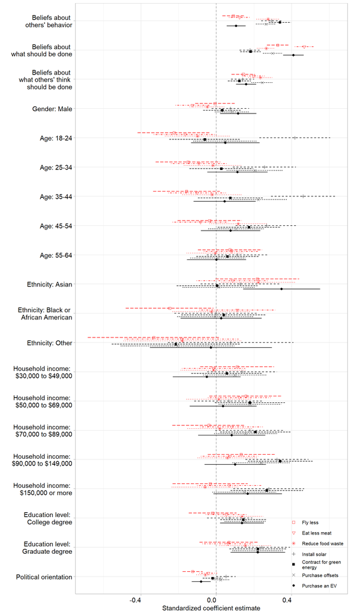

##### Intention to adopt: coefficients from linear models that included demographic variables and political orientation only

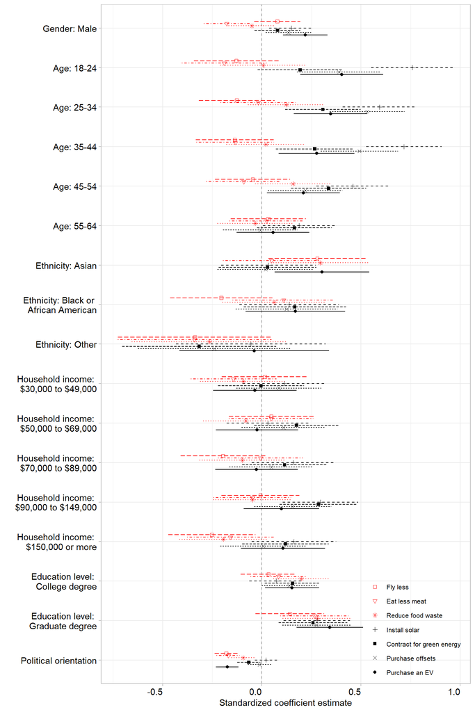

##### Program interest: coefficients from linear models that included demographic and psychological variables

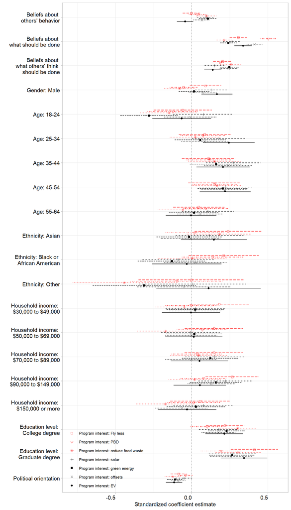

##### Program interest: coefficients from linear models that included demographic variables and political orientation only

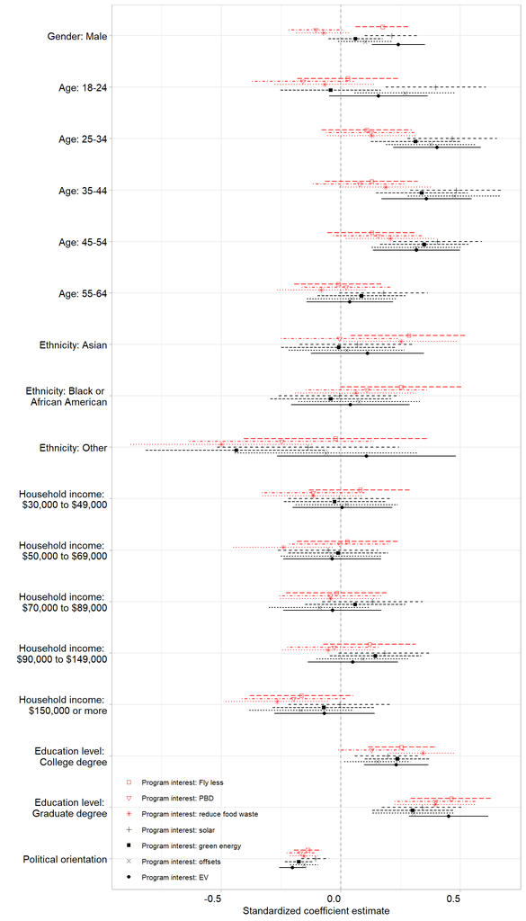

#### People underestimate how many people think they should take actions

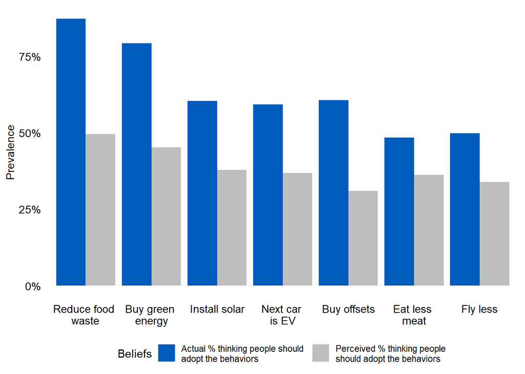

### Appendix

Guide to interpreting the results in the tables.

The tables below, broken down by each behavior, help understand: 1) if there are differences in the performance of indicators between the Boston sample and the segment of the population (for example, *Males*); and 2) how large are these differences.

- For each behavior, the first table presents the mean indicator performance in the overall sample. For example, the value of 0.47 in row *Mean*, column *Trying to eat less meat* in the first *Eat less meat* table tells us that 47% of the population of Boston is trying to eat less meat. The second row of the same table, presents the standard deviation of that indicator in the overall sample. Standard deviation is a widely used measure of the variability or dispersion and shows how much variation there is from the mean. A small standard deviation indicates data points that cluster around the mean, whereas a large standard deviation indicates data points that are dispersed across many different values.
- For each behavior, the values in the second table represent differences, in terms of standard deviation, between indicator performance in the segment compared to the overall population. These values were calculated by taking the difference between mean indicator performance for that row segment and the mean indicator performance in the overall population, divided by the standard deviation of indicator performance in the overall sample. For example, the value of -0.12 in row *Male*, column *Trying to eat less meat* in the table *Eat less meat* tells us that the number of Males that are trying to eat less meat is 0.12 standard deviations below the average of the overall population.
- Performing the calculations above allows us to draw comparisons between indicator performance within and across the behaviors. In these tables, psychology conventions would say that a small effect would be a difference of ~0.2, a medium effect of ~0.5, and a large effect of ~0.8. The average effect size of well-designed studies in the Social Psychology literature is ~0.3. We therefore generally concentrate our interpretation on effects that are of at least this size. If standard deviation values in the segment rows are close to 0, then the indicator performance for that segment is close to the performance in the overall population.
- For each segment, in brackets, we have provided the frequency of that segment in the sample. For example, the overall sample contains 525 *Males*.

##### Eat less meat

- **Program interest**: Graduate degree

| Segment | Trying to eat less meat | Intention | Belief that others are engaging in the behavior | Belief that others should engage in the behavior | Belief that others think people should engage in the behavior | Program interest |
| --- | --- | --- | --- | --- | --- | --- |
| Mean | 0.47 | 0.37 | 0.37 | 0.48 | 0.36 | 0.36 |
| Standard Deviation | 0.5 | 0.33 | 0.2 | 0.5 | 0.22 | 0.36 |

|  | Trying to eat less meat | Intention | Belief that others are engaging in the behavior | Belief that others should engage in the behavior | Belief that others think people should engage in the behavior | Program interest |
| --- | --- | --- | --- | --- | --- | --- |
| Male (525) | -0.12 | -0.11 | -0.04 | -0.08 | -0.01 | -0.07 |
| Female (614) | 0.11 | 0.1 | 0.03 | 0.07 | 0.01 | 0.06 |
| 18-24 (151) | -0.15 | -0.14 | 0.07 | -0.06 | 0 | -0.25 |
| 25-34 (198) | 0.07 | 0.09 | 0.17 | 0.12 | 0.15 | 0.14 |
| 35-44 (173) | -0.1 | -0.04 | -0.04 | -0.03 | 0.06 | 0.08 |
| 45-54 (188) | -0.13 | -0.07 | -0.19 | 0 | -0.05 | 0.08 |
| 55-64 (189) | 0.04 | 0.06 | 0.04 | -0.11 | -0.08 | -0.05 |
| 65+ (240) | 0.18 | 0.05 | -0.04 | 0.05 | -0.06 | -0.04 |
| White (983) | 0 | 0 | -0.01 | 0 | 0 | 0 |
| Other (156) | 0.01 | 0 | 0.09 | -0.02 | 0 | 0.02 |

[output cut: 9 more lines]

##### Reduce food waste

Most of the differences between the Boston sample and segments of the population are small.

| Segment | Trying to reduce food waste | Intention | Belief that others are engaging in the behavior | Belief that others should engage in the behavior | Belief that others think people should engage in the behavior | Program interest |
| --- | --- | --- | --- | --- | --- | --- |
| Mean | 0.76 | 0.55 | 0.42 | 0.87 | 0.49 | 0.52 |
| Standard Deviation | 0.43 | 0.31 | 0.23 | 0.33 | 0.26 | 0.36 |

|  | Trying to reduce food waste | Intention | Belief that others are engaging in the behavior | Belief that others should engage in the behavior | Belief that others think people should engage in the behavior | Program interest |
| --- | --- | --- | --- | --- | --- | --- |
| Male (525) | -0.07 | -0.04 | -0.03 | -0.02 | 0.02 | -0.05 |
| Female (614) | 0.06 | 0.03 | 0.03 | 0.01 | -0.02 | 0.04 |
| 18-24 (151) | -0.06 | -0.07 | 0.07 | 0.03 | 0.11 | -0.2 |
| 25-34 (198) | 0.03 | 0.12 | 0.16 | 0.07 | 0.2 | 0.13 |
| 35-44 (173) | -0.04 | 0.01 | -0.02 | 0 | 0.05 | 0.18 |
| 45-54 (188) | -0.04 | 0.1 | -0.05 | -0.03 | 0.03 | 0.13 |
| 55-64 (189) | -0.06 | -0.1 | -0.08 | -0.06 | -0.18 | -0.16 |
| 65+ (240) | 0.12 | -0.06 | -0.06 | 0 | -0.15 | -0.09 |
| White (983) | -0.01 | -0.02 | -0.01 | -0.02 | -0.03 | -0.01 |
| Other (156) | 0.08 | 0.12 | 0.09 | 0.1 | 0.16 | 0.09 |

[output cut: 9 more lines]

##### Purchase carbon offsets

- **Intention**: 25-34; 35-44
- **Belief that others are engaging in the behavior**: 18-24
- **Program interest**: 35-44

| Segment | Bought carbon offsets | Intention | Belief that others are engaging in the behavior | Belief that others should engage in the behavior | Belief that others think people should engage in the behavior | Program interest |
| --- | --- | --- | --- | --- | --- | --- |
| Mean | 0.06 | 0.25 | 0.18 | 0.61 | 0.31 | 0.37 |
| Standard Deviation | 0.24 | 0.28 | 0.2 | 0.49 | 0.27 | 0.35 |

|  | Bought carbon offsets | Intention | Belief that others are engaging in the behavior | Belief that others should engage in the behavior | Belief that others think people should engage in the behavior | Program interest |
| --- | --- | --- | --- | --- | --- | --- |
| Male (525) | 0.12 | 0.08 | 0.05 | -0.04 | 0.08 | 0.04 |
| Female (614) | -0.1 | -0.07 | -0.04 | 0.03 | -0.07 | -0.04 |
| 18-24 (151) | 0.11 | 0.04 | 0.32 | 0.21 | 0.21 | -0.01 |
| 25-34 (198) | 0.24 | 0.3 | 0.19 | 0.27 | 0.19 | 0.2 |
| 35-44 (173) | 0.24 | 0.27 | 0.13 | 0.14 | 0.14 | 0.28 |
| 45-54 (188) | -0.12 | -0.02 | -0.08 | -0.09 | -0.06 | 0.06 |
| 55-64 (189) | -0.21 | -0.27 | -0.22 | -0.2 | -0.24 | -0.21 |
| 65+ (240) | -0.18 | -0.24 | -0.21 | -0.23 | -0.15 | -0.25 |
| White (983) | -0.02 | -0.02 | -0.04 | -0.03 | -0.02 | -0.02 |
| Other (156) | 0.13 | 0.14 | 0.24 | 0.19 | 0.14 | 0.14 |

[output cut: 9 more lines]

##### Purchase green energy

Most of the differences between the Boston sample and segments of the population are small.

| Segment | Contracted for green energy | Intention | Belief that others are engaging in the behavior | Belief that others should engage in the behavior | Belief that others think people should engage in the behavior | Program interest |
| --- | --- | --- | --- | --- | --- | --- |
| Mean | 0.15 | 0.36 | 0.33 | 0.79 | 0.45 | 0.48 |
| Standard Deviation | 0.36 | 0.32 | 0.19 | 0.41 | 0.25 | 0.36 |

|  | Contracted for green energy | Intention | Belief that others are engaging in the behavior | Belief that others should engage in the behavior | Belief that others think people should engage in the behavior | Program interest |
| --- | --- | --- | --- | --- | --- | --- |
| Male (525) | 0.06 | 0.05 | 0.04 | -0.01 | 0.07 | 0.03 |
| Female (614) | -0.05 | -0.04 | -0.03 | 0.01 | -0.06 | -0.02 |
| 18-24 (151) | 0.01 | -0.1 | 0.15 | 0.25 | 0.15 | -0.29 |
| 25-34 (198) | 0.08 | 0.14 | 0.21 | 0.23 | 0.23 | 0.19 |
| 35-44 (173) | -0.01 | 0.12 | 0.03 | 0.09 | 0.1 | 0.22 |
| 45-54 (188) | 0.09 | 0.15 | -0.01 | -0.05 | 0.01 | 0.17 |
| 55-64 (189) | -0.03 | -0.05 | -0.05 | -0.11 | -0.16 | -0.1 |
| 65+ (240) | -0.1 | -0.21 | -0.24 | -0.28 | -0.23 | -0.19 |
| White (983) | -0.01 | -0.01 | -0.03 | -0.03 | -0.01 | 0.01 |
| Other (156) | 0.03 | 0.05 | 0.21 | 0.18 | 0.09 | -0.04 |

[output cut: 9 more lines]

##### Install solar panels

- **Intention**: 35-44
- **Belief that others should engage in the behavior**: 18-24
- **Belief that others think people should engage in the behavior**: 18-24; 25-34

| Segment | Have solar panels | Intention | Belief that others are engaging in the behavior | Belief that others should engage in the behavior | Belief that others think people should engage in the behavior | Program interest |
| --- | --- | --- | --- | --- | --- | --- |
| Mean | 0.1 | 0.22 | 0.29 | 0.6 | 0.38 | 0.38 |
| Standard Deviation | 0.3 | 0.3 | 0.2 | 0.49 | 0.25 | 0.37 |

|  | Have solar panels | Intention | Belief that others are engaging in the behavior | Belief that others should engage in the behavior | Belief that others think people should engage in the behavior | Program interest |
| --- | --- | --- | --- | --- | --- | --- |
| Male (525) | 0.12 | 0.1 | 0.02 | 0.09 | 0.12 | 0.12 |
| Female (614) | -0.1 | -0.09 | -0.02 | -0.07 | -0.1 | -0.1 |
| 18-24 (151) | 0.16 | 0.23 | 0.19 | 0.35 | 0.28 | 0 |
| 25-34 (198) | 0.14 | 0.19 | 0.22 | 0.26 | 0.29 | 0.21 |
| 35-44 (173) | 0.23 | 0.35 | 0.11 | 0.07 | 0.16 | 0.24 |
| 45-54 (188) | -0.03 | 0.07 | -0.03 | 0.02 | 0.03 | 0.11 |
| 55-64 (189) | -0.22 | -0.24 | -0.15 | -0.16 | -0.24 | -0.14 |
| 65+ (240) | -0.19 | -0.42 | -0.24 | -0.37 | -0.36 | -0.33 |
| White (983) | 0 | -0.03 | -0.02 | -0.02 | -0.02 | -0.02 |
| Other (156) | 0.02 | 0.19 | 0.14 | 0.15 | 0.11 | 0.09 |

[output cut: 9 more lines]

##### Purchase an EV

- **Adoption**: Under $30,000
- **Belief that others are engaging in the behavior**: 18-24
- **Belief that others should engage in the behavior**: 18-24
- **Program interest**: Graduate degree

| Segment | Have an EV | Intention | Belief that others are engaging in the behavior | Belief that others should engage in the behavior | Belief that others think people should engage in the behavior | Program interest |
| --- | --- | --- | --- | --- | --- | --- |
| Mean | 0.16 | 0.39 | 0.18 | 0.59 | 0.37 | 0.53 |
| Standard Deviation | 0.37 | 0.31 | 0.15 | 0.49 | 0.26 | 0.35 |

|  | Have an EV | Intention | Belief that others are engaging in the behavior | Belief that others should engage in the behavior | Belief that others think people should engage in the behavior | Program interest |
| --- | --- | --- | --- | --- | --- | --- |
| Male (525) | 0.01 | 0.11 | 0.05 | 0.06 | 0.12 | 0.12 |
| Female (614) | -0.01 | -0.09 | -0.04 | -0.05 | -0.1 | -0.1 |
| 18-24 (151) | 0.18 | 0.15 | 0.37 | 0.29 | 0.24 | -0.13 |
| 25-34 (198) | 0.1 | 0.23 | 0.08 | 0.21 | 0.08 | 0.29 |
| 35-44 (173) | 0.01 | 0.16 | 0.1 | 0.2 | 0.05 | 0.23 |
| 45-54 (188) | -0.03 | 0 | -0.08 | -0.06 | -0.05 | 0.09 |
| 55-64 (189) | -0.04 | -0.18 | -0.16 | -0.17 | -0.12 | -0.2 |
| 65+ (240) | -0.15 | -0.26 | -0.18 | -0.32 | -0.12 | -0.24 |
| White (983) | -0.05 | -0.04 | -0.03 | -0.04 | 0 | -0.02 |
| Other (156) | 0.28 | 0.26 | 0.21 | 0.23 | 0.02 | 0.16 |

[output cut: 9 more lines]

##### Fly less

- **Program interest**: Graduate degree

| Segment | Trying to fly less | Intention | Belief that others are engaging in the behavior | Belief that others should engage in the behavior | Belief that others think people should engage in the behavior | Program interest |
| --- | --- | --- | --- | --- | --- | --- |
| Mean | 0.51 | 0.45 | 0.4 | 0.5 | 0.34 | 0.35 |
| Standard Dflyiation | 0.5 | 0.38 | 0.29 | 0.5 | 0.25 | 0.35 |

|  | Trying to fly less | Intention | Belief that others are engaging in the behavior | Belief that others should engage in the behavior | Belief that others think people should engage in the behavior | Program interest |
| --- | --- | --- | --- | --- | --- | --- |
| Male (525) | 0.06 | 0.01 | 0.07 | 0.03 | 0.13 | 0.08 |
| Female (614) | -0.05 | -0.01 | -0.06 | -0.02 | -0.11 | -0.07 |
| 18-24 (151) | 0.07 | -0.04 | 0.04 | 0.21 | 0.19 | -0.11 |
| 25-34 (198) | 0.08 | -0.02 | 0.04 | 0.05 | 0.08 | 0.13 |
| 35-44 (173) | 0.06 | -0.05 | 0.01 | 0.03 | 0.01 | 0.14 |
| 45-54 (188) | -0.11 | -0.03 | -0.05 | -0.07 | -0.1 | 0.05 |
| 55-64 (189) | 0.05 | 0.07 | 0.03 | -0.12 | -0.14 | -0.11 |
| 65+ (240) | -0.11 | 0.05 | -0.05 | -0.05 | -0.01 | -0.09 |
| White (983) | -0.04 | 0 | -0.02 | -0.02 | -0.02 | -0.03 |
| Other (156) | 0.27 | -0.01 | 0.11 | 0.16 | 0.11 | 0.22 |

[output cut: 9 more lines]